# Simple graphs/tables

Mathilde Le Vu

2022-07-10

## State and world region of birth

```r
# State of birth in : Switzerland or Outside of Switzerland
  table(bevn_eco$country_of_birth_cat1, useNA = "always")
```

```
##
##         Switzerland Outside Switzerland                <NA>
##             1278657              132228                   1
```

```r
  round(prop.table(table(bevn_eco$country_of_birth_cat1, useNA="always"))*100,2)
```

```
##
##         Switzerland Outside Switzerland                <NA>
##               90.63                9.37                0.00
```

```r
#State of birth in : Switzerland, Europe, Africa, Americas, Asia, Oceania, other
table(bevn_eco$country_of_birth_cat2, useNA = "always")
```

```
##
##         Switzerland Europe - excl Switz              Africa            Americas                Asia             Oceania               Other                <NA>
##             1278657               80604                4324               26538               19700                1062                   0                   1
```

```r
round(prop.table(table(bevn_eco$country_of_birth_cat2, useNA="always"))*100,2)
```

```
##
##         Switzerland Europe - excl Switz              Africa            Americas                Asia             Oceania               Other                <NA>
##               90.63                5.71                0.31                1.88                1.40                0.08                0.00                0.00
```

```r
#State of birth in : Switzerland, different parts of Europe, other
round(prop.table(table(bevn_eco$country_of_birth_cat3, useNA="always"))*100,2)
```

```
##
##  Central Europe  Eastern Europe Northern Europe           other       SE Europe Southern Europe       SW Europe           Switz  Western Europe            <NA>
##            1.59            0.04            0.17            3.67            0.11            0.65            0.27           90.63            2.87            0.00
```

## Nationality Mother

```r
summary(bevn_eco$mother_nationality)
```

```
##    Min. 1st Qu.  Median    Mean 3rd Qu.    Max.
##    8100    8100    8100    8177    8231    8999
```

```r
table(bevn_eco$mother_nationality, useNA="always")
```

```
##
##   8100   8201   8202   8204   8205   8206   8207   8211   8212   8214   8215   8216   8217   8218   8222   8223   8224   8226   8227   8228   8229   8230   8231   8232   8233
## 839657   1115      7   3357   1918   1305  77431   1415  42273   2244   9578   1021    118  39469   1940    278     58      5   3815    722   8117   8148  48540   5089      6
##   8234   8236   8239   8240   8242   8243   8244   8248   8250   8251   8252   8254   8255   8256   8260   8261   8262   8263   8264   8265   8266   8301   8302   8303   8304
##   2660  14055  17650   4467     91   4689   2880  29522   6753   1028   8201    646  22699  32024    357    848    720    618   7224   3716    718     18   1747     26   2205
##   8305   8307   8308   8309   8310   8311   8312   8313   8314   8315   8317   8319   8320   8321   8322   8323   8324   8325   8326   8327   8329   8330   8331   8332   8333
##   1108     11    135    122    948     61    139    581     75    429   2168    377    809      8    101   2282     13     39    320    475     18     89   5085     22    404
##   8334   8335   8336   8337   8340   8341   8343   8344   8345   8346   8347   8348   8349   8350   8351   8352   8353   8354   8356   8357   8358   8359   8360   8362   8363
##     54     53   1004    211     89    215     60     10    686     19     64   2949   1259    343     52      2    128    564     55   3648    191    844     11  10251     12
##   8372   8401   8402   8403   8405   8406   8407   8408   8409   8410   8411   8415   8417   8418   8419   8420   8421   8423   8424   8425   8427   8429   8430   8431   8432
##      1   2099     16      5   1263  12056   1519    262   2763   1434    197    232      5    196      1    241     97   4366   2423    723   2190    255    129    469   2065
##   8435   8436   8437   8438   8439   8440   8441   8442   8443   8445   8501   8502   8503   8504   8505   8506   8507   8508   8510   8511   8512   8513   8514   8515   8516
##     10     38    189    856   9614     11      1      3      3      9   2227     12     11      5     58   7679    406   5749   3583    984   2760   1100   3123   3187    198
##   8517   8518   8519   8521   8522   8523   8525   8526   8527   8528   8529   8530   8532   8533   8534   8535   8537   8539   8541   8542   8543   8545   8546   8550   8560
##    265    442     10     30    114   1644    493     10     26    598    161      2     16   1643   2919    155    532    925   3882   4492     52   1806    980    178    281
##   8561   8562   8563   8564   8565   8566   8567   8601   8602   8605   8607   8608   8610   8612   8614   8616   8998   8999   <NA>
##    203    306    416    155     39     28    276   2340     16      3    588     12      3      5      7      2     52   6175      0
```

```r
# Nationality of the mother in : Switzerland or Outside of Switzerland
  round(prop.table(table(bevn_eco$mother_nationality_cat1, useNA="always"))*100,2)
```

```
##
##         Switzerland Outside Switzerland                <NA>
##               59.51               40.49                0.00
```

```r
# Nationality of the mother in : Switzerland, Europe, Africa, Americas, Asia, Oceania, other
  round(prop.table(table(bevn_eco$mother_nationality_cat2, useNA="always"))*100,2)
```

```
##
##         Switzerland Europe - excl Switz              Africa            Americas                Asia             Oceania               Other                <NA>
##               59.51               29.74                3.02                3.24                4.00                0.05                0.44                0.00
```

```r
#Nationality of the mother in : Switzerland, different parts of Europe, other
  round(prop.table(table(bevn_eco$mother_nationality_cat3, useNA="always"))*100,2)
```

```
##
##  Central Europe  Eastern Europe Northern Europe           other       SE Europe Southern Europe       SW Europe           Switz  Western Europe            <NA>
##            7.31            1.01            0.44           11.07            7.73            4.22            4.44           59.51            4.28            0.00
```

## Place of residence Mother

1-6910 for commune if resident inside Switz  
8201-8703 if resident outside of Switz

```r
#to check minimum and maximum
summary(bevn_eco$com)
```

```
##    Min. 1st Qu.  Median    Mean 3rd Qu.    Max.    NA's
##       1     769    3231    3508    5727    8619    1942
```

```r
head(bevn_eco$com,50)
```

```
##  [1] 8514  198  191 6621 6621 1331 1711  261 8207  152 4063 1041 4096 3231 1404 2769  261  927  261 2861 2765 2765  587  230 3375 5586  261  261 1322 3203 5064 3203 6621 8229
## [35]  193 5115 6643 8207 5250  261  952  351 5585 5586 5634 1093 5725  616   84 6087
```

```r
# Place of residence of the mother in : inside or outside Switzerland
  round(prop.table(table(bevn_eco$mother_residence_cat1, useNA="always"))*100,2)
```

```
##
##         Switzerland Outside Switzerland                <NA>
##               88.75               11.12                0.14
```

```r
  table(bevn_eco$mother_residence_cat1, useNA="always")
```

```
##
##         Switzerland Outside Switzerland                <NA>
##             1252110              156834                1942
```

## Status of Residence of the mother

1=permanent resident, 2=non-permanent resident, 4=short stay, 9=domiciled abroad

```r
summary(bevn_eco$resident_status)
```

```
##    Min. 1st Qu.  Median    Mean 3rd Qu.    Max.
##    1.00    1.00    1.00    1.91    1.00    9.00
```

```r
table(bevn_eco$resident_status, useNA = "always")
```

```
##
##       1       2       4       9    <NA>
## 1241399    9223    1488  158776       0
```

```r
round(prop.table(table(bevn_eco$resident_status, useNA="always"))*100,2)
```

```
##
##     1     2     4     9  <NA>
## 87.99  0.65  0.11 11.25  0.00
```

```r
table(bevn_eco$mother_nationality_cat1, bevn_eco$resident_status)
```

```
##
##                            1      2      4      9
##   Switzerland         763630      7      0  76020
##   Outside Switzerland 477769   9216   1488  82756
```

## Nationality father

See separate codebook. Expected: 8100-8703

```r
# categorizing nationality of the father in : inside or outside Switzerland
  round(prop.table(table(bevn_eco$father_nationality_cat1, useNA="always"))*100,2)
```

```
##
##         Switzerland Outside Switzerland                <NA>
##               57.85               39.11                3.04
```

```r
  table(bevn_eco$father_nationality_cat1, useNA="always")
```

```
##
##         Switzerland Outside Switzerland                <NA>
##              816190              551745               42951
```

## lebend geboren oder nicht = born alive or not

1=lifeborn, 2=stillborn

```r
table(bevn_eco$stillbirth, useNA = "always")
```

```
##
##       0       1    <NA>
## 1405313    5573       0
```

```r
round(prop.table(table(bevn_eco$stillbirth, useNA="always"))*100,3)
```

```
##
##      0      1   <NA>
## 99.605  0.395  0.000
```

## Gestational age

```r
## GA in weeks
summary(bevn_eco$GA_weeks)
```

```
##    Min. 1st Qu.  Median    Mean 3rd Qu.    Max.    NA's
##   16.00   38.57   39.57   39.22   40.43   45.86  218357
```

## Length at birth (cm)

```r
summary(bevn_eco$BL)
```

```
##    Min. 1st Qu.  Median    Mean 3rd Qu.    Max.    NA's
##    1.00   48.00   50.00   49.31   51.00   64.00  132461
```

```r
table(bevn_eco$BL, useNA = "always")
```

```
##
##      1      5      8      9     10     11     12     13     14     15     16     17     18     19     20     21     22     23     24     25     26     27     28     29     30
##      2      1      1      1      6      4      2      2      2     21     15     27     50     44    106     87    133    144    189    259    350    469    593    593    850
##     31     32     33     34     35     36     37     38     39     40     41     42     43     44     45     46     47     48     49     50     51     52     53     54     55
##    753    846    867    939   1034   1114   1265   1553   1829   2789   3678   5794   9098  15821  29599  56251 102541 162742 206119 251081 186255 123624  63127  29037  10609
##     56     57     58     59     60     61     62     63     64   <NA>
##   4199   1288    410    151     46      7      3      4      1 132461
```

## weight at birth (g)

```r
summary(bevn_eco$BW)
```

```
##    Min. 1st Qu.  Median    Mean 3rd Qu.    Max.    NA's
##       3    3000    3320    3285    3640    9351  132494
```

```r
#BW categ. in LBW, "normal" (arbitrary decision) and high BW
table(bevn_eco$BW_cat, useNA="always")
```

```
##
##     LBW     NBW     HBW    <NA>
##   88969 1188859     564  132494
```

```r
round(prop.table(table(bevn_eco$BW_cat, useNA="always"))*100, 3)
```

```
##
##    LBW    NBW    HBW   <NA>
##  6.306 84.263  0.040  9.391
```

## Number of babies

1=singleton, 2=twins, 3=triplets, …, 6=sextuplets and more

```r
table(bevn_eco$nb_of_babies, useNA="always")
```

```
##
##       1       2       3       4       5    <NA>
## 1359966   49526    1353      36       5       0
```

```r
round(prop.table(table(bevn_eco$nb_of_babies, useNA="always"))*100,2)
```

```
##
##     1     2     3     4     5  <NA>
## 96.39  3.51  0.10  0.00  0.00  0.00
```

```r
##Single VS multiple pregnancies
table(bevn_eco$singleton_or_multiple)
```

```
##
## singleton  multiple
##   1359966     50920
```

```r
round(prop.table(table(bevn_eco$singleton_or_multiple, useNA="always"))*100,2)
```

```
##
## singleton  multiple      <NA>
##     96.39      3.61      0.00
```

## Mothers inside Switz without GMNDR: to check the number of missing

```r
table(bevn_eco_in3$com1, bevn_eco_in3$mother_residence_cat1, useNA = "always")
```

```
##
##                 Switzerland Outside Switzerland   <NA>
##   [1,1e+03]          370385                   0      0
##   (1e+03,2e+03]      121163                   0      0
##   (2e+03,3e+03]      155895                   0      0
##   (3e+03,4e+03]      108325                   0      0
##   (4e+03,5e+03]      130917                   0      0
##   (5e+03,6e+03]      160935                   0      0
##   <NA>               155475                   0      0
```

```r
  round(prop.table(table(bevn_eco_in3$com1, bevn_eco_in3$mother_residence_cat1, useNA="always"), margin=2)*100,2)
```

```
##
##                 Switzerland Outside Switzerland <NA>
##   [1,1e+03]           30.79
##   (1e+03,2e+03]       10.07
##   (2e+03,3e+03]       12.96
##   (3e+03,4e+03]        9.00
##   (4e+03,5e+03]       10.88
##   (5e+03,6e+03]       13.38
##   <NA>                12.92
```

# Simple tables

## Gestational age through the years

```r
#calculating median by year
 GA_median <- aggregate(GA_weeks ~ birthyear, data = bevn_eco, median) # from 2006 it was systematically collected
 GA_median
```

```
##    birthyear GA_weeks
## 1       2006 39.57143
## 2       2007 39.57143
## 3       2008 39.42857
## 4       2009 39.57143
## 5       2010 39.57143
## 6       2011 39.57143
## 7       2012 39.57143
## 8       2013 39.57143
## 9       2014 39.57143
## 10      2015 39.57143
## 11      2016 39.57143
## 12      2017 39.57143
## 13      2018 39.57143
## 14      2019 39.57143
## 15      2020 39.57143
```

```r
#same but using tidyverse
 gamedian <- bevn_eco %>%
   group_by(birthyear) %>%
     filter( !is.na(GA_weeks)) %>%
   summarise(medGA=format(median(GA_weeks),digits=5))%>%
 filter(birthyear>2005)
ungroup(gamedian)
```

```
## # A tibble: 15 x 2
##    birthyear medGA
##        <int> <chr>
##  1      2006 39.571
##  2      2007 39.571
##  3      2008 39.429
##  4      2009 39.571
##  5      2010 39.571
##  6      2011 39.571
##  7      2012 39.571
##  8      2013 39.571
##  9      2014 39.571
## 10      2015 39.571
## 11      2016 39.571
## 12      2017 39.571
## 13      2018 39.571
## 14      2019 39.571
## 15      2020 39.571
```

```r
gamedian
```

```
## # A tibble: 15 x 2
##    birthyear medGA
##        <int> <chr>
##  1      2006 39.571
##  2      2007 39.571
##  3      2008 39.429
##  4      2009 39.571
##  5      2010 39.571
##  6      2011 39.571
##  7      2012 39.571
##  8      2013 39.571
##  9      2014 39.571
## 10      2015 39.571
## 11      2016 39.571
## 12      2017 39.571
## 13      2018 39.571
## 14      2019 39.571
## 15      2020 39.571
```

```r
 #creating a function to calculate the mode of a variable
getmode <- function(v) {
   uniqv <- na.omit(unique(v))
   uniqv[which.max(tabulate(match(v, uniqv)))]
}
# Calculate the GA mode through the years
ga_mode <- bevn_eco %>%
   group_by(birthyear) %>%
     filter( !is.na(GA_weeks)) %>%
   summarise(mode=format(getmode(GA_weeks), digits=7))%>%
 filter(birthyear>2005)
ungroup(ga_mode)
```

```
## # A tibble: 15 x 2
##    birthyear mode
##        <int> <chr>
##  1      2006 40
##  2      2007 40
##  3      2008 40
##  4      2009 40.14286
##  5      2010 40
##  6      2011 40.14286
##  7      2012 40
##  8      2013 40.14286
##  9      2014 40.14286
## 10      2015 40.14286
## 11      2016 40.14286
## 12      2017 40.14286
## 13      2018 40.14286
## 14      2019 40.14286
## 15      2020 40.14286
```

```r
ga_mode
```

```
## # A tibble: 15 x 2
##    birthyear mode
##        <int> <chr>
##  1      2006 40
##  2      2007 40
##  3      2008 40
##  4      2009 40.14286
##  5      2010 40
##  6      2011 40.14286
##  7      2012 40
##  8      2013 40.14286
##  9      2014 40.14286
## 10      2015 40.14286
## 11      2016 40.14286
## 12      2017 40.14286
## 13      2018 40.14286
## 14      2019 40.14286
## 15      2020 40.14286
```

```r
## GA frequency tables through the years
bevn_eco <- bevn_eco %>%
  mutate(GA_weeks_cat = cut (GA_weeks, breaks=c(16,24,30,34,39,44,46), include.lowest=TRUE))
bevn_eco
```

[output not shown]

[output cut: 94 more lines]

```r
bevn_eco1 <- bevn_eco %>%
  filter(!is.na(GA_weeks)) %>%
  filter(birthyear>2005)
bevn_eco1
```

[output not shown]

[output cut: 94 more lines]

```r
GA_freq <- bevn_eco1 %>%
  group_by(birthyear) %>%
  ungroup(birthyear)

round(prop.table(table(GA_freq$GA_weeks_cat, GA_freq$birthyear, useNA="always"), margin=2)*100,2)
```

```
##
##            2006  2007  2008  2009  2010  2011  2012  2013  2014  2015  2016  2017  2018  2019  2020 <NA>
##   [16,24]  0.33  0.22  0.27  0.30  0.29  0.24  0.28  0.29  0.25  0.27  0.29  0.25  0.26  0.24  0.26
##   (24,30]  0.48  0.61  0.66  0.65  0.64  0.68  0.63  0.63  0.65  0.64  0.63  0.65  0.66  0.56  0.57
##   (30,34]  1.53  1.47  1.42  1.54  1.41  1.43  1.49  1.41  1.45  1.42  1.41  1.35  1.38  1.25  1.23
##   (34,39] 36.47 37.66 38.35 36.86 36.07 35.69 36.44 35.88 35.72 35.64 36.18 35.16 35.12 34.96 34.98
##   (39,44] 61.20 60.03 59.30 60.64 61.59 61.95 61.15 61.79 61.93 62.02 61.49 62.59 62.58 63.00 62.96
##   (44,46]  0.00  0.00  0.00  0.00  0.00  0.00  0.00  0.00  0.00  0.00  0.00  0.00  0.00  0.00  0.00
##   <NA>     0.00  0.00  0.00  0.00  0.00  0.00  0.00  0.00  0.00  0.00  0.00  0.00  0.00  0.00  0.00
```

## Birthweight through the years

```r
BW_median2 <- aggregate(BW ~ birthyear, data = bevn_eco, median)
BW_median2
```

```
##    birthyear   BW
## 1       2006 3320
## 2       2007 3330
## 3       2008 3320
## 4       2009 3320
## 5       2010 3320
## 6       2011 3330
## 7       2012 3325
## 8       2013 3320
## 9       2014 3320
## 10      2015 3320
## 11      2016 3320
## 12      2017 3320
## 13      2018 3320
## 14      2019 3330
## 15      2020 3340
```

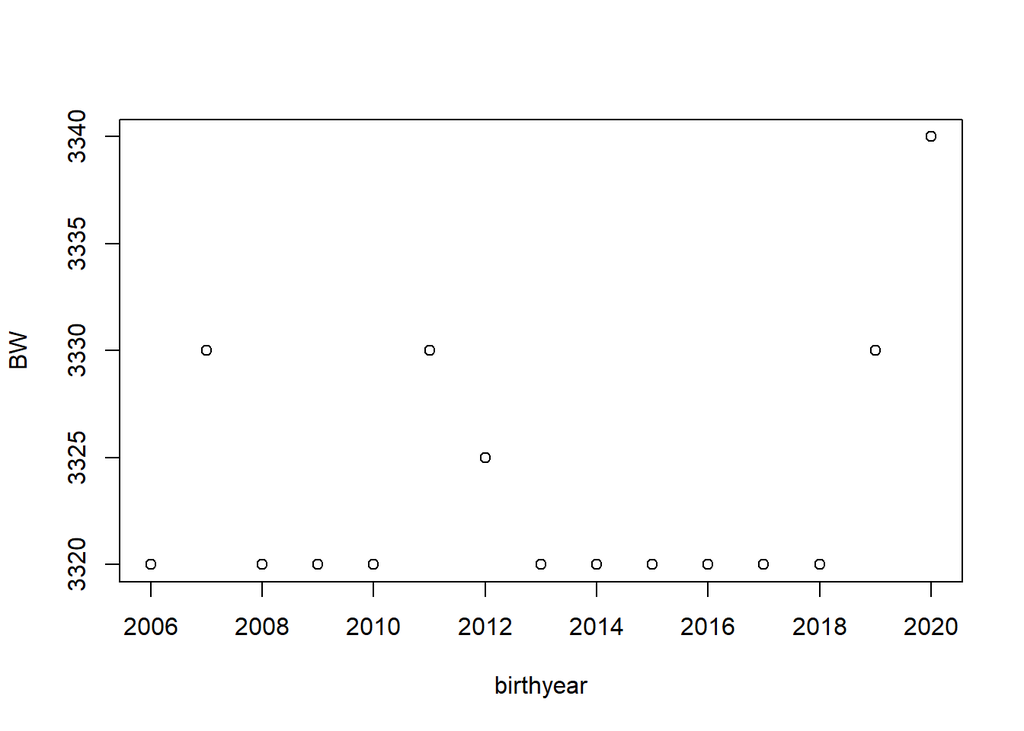

```r
plot(BW_median2)
```

## Length through the years

```r
BL_median <- aggregate(BL ~ birthyear, data = bevn_eco, median)
BL_median
```

```
##    birthyear BL
## 1       2006 50
## 2       2007 50
## 3       2008 50
## 4       2009 50
## 5       2010 50
## 6       2011 50
## 7       2012 50
## 8       2013 50
## 9       2014 50
## 10      2015 50
## 11      2016 50
## 12      2017 50
## 13      2018 50
## 14      2019 50
## 15      2020 50
```

## Sex % through the years

```r
tab1<- table(bevn_eco$sex, bevn_eco$birthyear)
tab1
```

```
##
##      2006  2007  2008  2009  2010  2011  2012  2013  2014  2015  2016  2017  2018  2019  2020
##   F 41004 41944 42804 43618 45334 44866 45622 46181 47379 47808 49017 48223 48372 47241 46366
##   M 43604 43949 45494 46479 47457 47458 48754 48829 50117 50880 51336 50827 50820 49801 49302
```

```r
round(prop.table(table(bevn_eco$sex, bevn_eco$birthyear), margin=2)*100,2)
```

```
##
##      2006  2007  2008  2009  2010  2011  2012  2013  2014  2015  2016  2017  2018  2019  2020
##   F 48.46 48.83 48.48 48.41 48.86 48.60 48.34 48.61 48.60 48.44 48.84 48.69 48.77 48.68 48.47
##   M 51.54 51.17 51.52 51.59 51.14 51.40 51.66 51.39 51.40 51.56 51.16 51.31 51.23 51.32 51.53
```

## Stillbirth % through the years, their median GA and BW

```r
table(bevn_eco$stillbirth, bevn_eco$birthyear, useNA="always")
```

```
##
##         2006  2007  2008  2009  2010  2011  2012  2013  2014  2015  2016  2017  2018  2019  2020  <NA>
##   0    84253 85580 87932 89725 92421 91958 93990 94594 97107 98310 99955 98676 98789 96684 95339     0
##   1      355   313   366   372   370   366   386   416   389   378   398   374   403   358   329     0
##   <NA>     0     0     0     0     0     0     0     0     0     0     0     0     0     0     0     0
```

```r
round(prop.table(table(bevn_eco$stillbirth, bevn_eco$birthyear), margin=2)*100,3)
```

```
##
##       2006   2007   2008   2009   2010   2011   2012   2013   2014   2015   2016   2017   2018   2019   2020
##   0 99.580 99.636 99.585 99.587 99.601 99.604 99.591 99.562 99.601 99.617 99.603 99.622 99.594 99.631 99.656
##   1  0.420  0.364  0.415  0.413  0.399  0.396  0.409  0.438  0.399  0.383  0.397  0.378  0.406  0.369  0.344
```

```r
#calculating median GA by year of birth, for stillborn
 GA_median_SB <- aggregate(GA_weeks ~ birthyear, data = subset(bevn_eco, stillbirth==1 & birthyear >=2006), median)
 GA_median_SB
```

```
##    birthyear GA_weeks
## 1       2006 28.35714
## 2       2007 30.85714
## 3       2008 28.28571
## 4       2009 29.64286
## 5       2010 27.85714
## 6       2011 29.14286
## 7       2012 27.71429
## 8       2013 28.57143
## 9       2014 29.42857
## 10      2015 29.28571
## 11      2016 30.00000
## 12      2017 28.28571
## 13      2018 28.42857
## 14      2019 31.14286
## 15      2020 30.57143
```

```r
 #calculating median GA by year of birth, for stillborn, with tidyverse
  GA_SB_Y <- bevn_eco %>%
  group_by(birthyear) %>%
  filter(stillbirth==1) %>%
  filter(birthyear>2005) %>%
   filter(!is.na(GA_weeks)) %>%
    summarise(medGA=format(median(GA_weeks),digits=5))
  ungroup(GA_SB_Y)
```

```
## # A tibble: 15 x 2
##    birthyear medGA
##        <int> <chr>
##  1      2006 28.357
##  2      2007 30.857
##  3      2008 28.286
##  4      2009 29.643
##  5      2010 27.857
##  6      2011 29.143
##  7      2012 27.714
##  8      2013 28.571
##  9      2014 29.429
## 10      2015 29.286
## 11      2016 30
## 12      2017 28.286
## 13      2018 28.429
## 14      2019 31.143
## 15      2020 30.571
```

```r
  GA_SB_Y
```

```
## # A tibble: 15 x 2
##    birthyear medGA
##        <int> <chr>
##  1      2006 28.357
##  2      2007 30.857
##  3      2008 28.286
##  4      2009 29.643
##  5      2010 27.857
##  6      2011 29.143
##  7      2012 27.714
##  8      2013 28.571
##  9      2014 29.429
## 10      2015 29.286
## 11      2016 30
## 12      2017 28.286
## 13      2018 28.429
## 14      2019 31.143
## 15      2020 30.571
```

```r
#calculating mode GA by year of birth, for stillborn
  ga_y_mode <- bevn_eco %>%
   group_by(birthyear) %>%
     filter( !is.na(GA_weeks)) %>%
     filter(stillbirth==1) %>%
   summarise(mode=format(getmode(GA_weeks), digits=5))%>%
  filter(birthyear>2005)
  ungroup(ga_y_mode)
```

```
## # A tibble: 15 x 2
##    birthyear mode
##        <int> <chr>
##  1      2006 22
##  2      2007 23.571
##  3      2008 23
##  4      2009 23
##  5      2010 24
##  6      2011 22.429
##  7      2012 23
##  8      2013 22.429
##  9      2014 22.714
## 10      2015 23
## 11      2016 23
## 12      2017 22.429
## 13      2018 22.714
## 14      2019 23.429
## 15      2020 22
```

```r
  ga_y_mode
```

```
## # A tibble: 15 x 2
##    birthyear mode
##        <int> <chr>
##  1      2006 22
##  2      2007 23.571
##  3      2008 23
##  4      2009 23
##  5      2010 24
##  6      2011 22.429
##  7      2012 23
##  8      2013 22.429
##  9      2014 22.714
## 10      2015 23
## 11      2016 23
## 12      2017 22.429
## 13      2018 22.714
## 14      2019 23.429
## 15      2020 22
```

```r
#GA_frequency for stillbirths
 GA_SB <- bevn_eco %>%
  filter(birthyear>2005) %>%
     filter(stillbirth==1)
  table(GA_SB$GA_weeks_cat)
```

```
##
## [16,24] (24,30] (30,34] (34,39] (39,44] (44,46]
##    1418    1258     674    1249     520       0
```

```r
  round(prop.table(table(GA_SB$GA_weeks_cat))*100,2)
```

```
##
## [16,24] (24,30] (30,34] (34,39] (39,44] (44,46]
##   27.70   24.58   13.17   24.40   10.16    0.00
```

```r
#GA frequency for stillbirths, through the years
 GA_SB_Y_freq <- bevn_eco %>%
   group_by(birthyear) %>%
  filter(stillbirth==1) %>%
  filter(birthyear>2005) %>%
 select(GA_weeks_cat)
  ungroup(GA_SB_Y_freq)
```

```
## # A tibble: 5,573 x 2
##    birthyear GA_weeks_cat
##        <int> <fct>
##  1      2006 <NA>
##  2      2006 <NA>
##  3      2006 <NA>
##  4      2006 <NA>
##  5      2006 <NA>
##  6      2006 <NA>
##  7      2006 <NA>
##  8      2006 <NA>
##  9      2006 <NA>
## 10      2006 <NA>
## # ... with 5,563 more rows
```

```r
  GA_SB_Y_freq
```

```
## # A tibble: 5,573 x 2
## # Groups:   birthyear [15]
##    birthyear GA_weeks_cat
##        <int> <fct>
##  1      2006 <NA>
##  2      2006 <NA>
##  3      2006 <NA>
##  4      2006 <NA>
##  5      2006 <NA>
##  6      2006 <NA>
##  7      2006 <NA>
##  8      2006 <NA>
##  9      2006 <NA>
## 10      2006 <NA>
## # ... with 5,563 more rows
```

```r
  table(GA_SB_Y_freq$birthyear, GA_SB_Y_freq$GA_weeks_cat, useNA="always")
```

```
##
##        [16,24] (24,30] (30,34] (34,39] (39,44] (44,46] <NA>
##   2006      13       8       3       8       2       0  321
##   2007      66      64      40      78      28       0   37
##   2008     101      79      38      80      39       0   29
##   2009     103      83      57      85      36       0    8
##   2010     123      79      46      79      37       0    6
##   2011      97      98      42      87      40       0    2
##   2012     121      89      39      87      44       0    6
##   2013     122     103      60      91      37       0    3
##   2014      97     106      47      87      46       0    6
##   2015     101      86      56      94      34       0    7
##   2016     115      82      49     107      38       0    7
##   2017     102     101      52      85      29       0    5
##   2018     106     106      47      94      39       0   11
##   2019      83      81      55     100      35       0    4
##   2020      68      93      43      87      36       0    2
##   <NA>       0       0       0       0       0       0    0
```

```r
 round(prop.table(table(GA_SB_Y_freq$GA_weeks_cat, GA_SB_Y_freq$birthyear, useNA="always"), margin=2)*100,2)
```

```
##
##            2006  2007  2008  2009  2010  2011  2012  2013  2014  2015  2016  2017  2018  2019  2020 <NA>
##   [16,24]  3.66 21.09 27.60 27.69 33.24 26.50 31.35 29.33 24.94 26.72 28.89 27.27 26.30 23.18 20.67
##   (24,30]  2.25 20.45 21.58 22.31 21.35 26.78 23.06 24.76 27.25 22.75 20.60 27.01 26.30 22.63 28.27
##   (30,34]  0.85 12.78 10.38 15.32 12.43 11.48 10.10 14.42 12.08 14.81 12.31 13.90 11.66 15.36 13.07
##   (34,39]  2.25 24.92 21.86 22.85 21.35 23.77 22.54 21.88 22.37 24.87 26.88 22.73 23.33 27.93 26.44
##   (39,44]  0.56  8.95 10.66  9.68 10.00 10.93 11.40  8.89 11.83  8.99  9.55  7.75  9.68  9.78 10.94
##   (44,46]  0.00  0.00  0.00  0.00  0.00  0.00  0.00  0.00  0.00  0.00  0.00  0.00  0.00  0.00  0.00
##   <NA>    90.42 11.82  7.92  2.15  1.62  0.55  1.55  0.72  1.54  1.85  1.76  1.34  2.73  1.12  0.61
```

```r
 #calculating median BW for stillborn babies, by year
  BW_median_sb <- aggregate(BW ~ birthyear, data = subset(bevn_eco, stillbirth==1), median)
  BW_median_sb
```

```
##    birthyear     BW
## 1       2006 1214.0
## 2       2007 1320.0
## 3       2008 1020.0
## 4       2009  960.0
## 5       2010  730.0
## 6       2011 1013.0
## 7       2012  777.5
## 8       2013  770.0
## 9       2014  955.0
## 10      2015  990.0
## 11      2016 1070.0
## 12      2017  950.0
## 13      2018  905.0
## 14      2019 1212.5
## 15      2020 1060.0
```

```r
 #calculating mode BW for stillborn babies, by year
  BW_y_mode <- bevn_eco %>%
   group_by(birthyear) %>%
     filter( !is.na(BW)) %>%
     filter(stillbirth==1) %>%
   summarise(mode=format(getmode(BW), digits=5))
  ungroup(BW_y_mode)
```

```
## # A tibble: 15 x 2
##    birthyear mode
##        <int> <chr>
##  1      2006 400
##  2      2007 1920
##  3      2008 600
##  4      2009 510
##  5      2010 570
##  6      2011 580
##  7      2012 440
##  8      2013 470
##  9      2014 610
## 10      2015 520
## 11      2016 520
## 12      2017 540
## 13      2018 480
## 14      2019 460
## 15      2020 380
```

```r
  BW_y_mode
```

```
## # A tibble: 15 x 2
##    birthyear mode
##        <int> <chr>
##  1      2006 400
##  2      2007 1920
##  3      2008 600
##  4      2009 510
##  5      2010 570
##  6      2011 580
##  7      2012 440
##  8      2013 470
##  9      2014 610
## 10      2015 520
## 11      2016 520
## 12      2017 540
## 13      2018 480
## 14      2019 460
## 15      2020 380
```

```r
  #BW frequency for stillbirths, through the years
  BW_SB_Y_freq <- bevn_eco %>%
   group_by(birthyear) %>%
  filter(stillbirth==1) %>%
   filter(!is.na(BW)) %>%
  select(BW_cat)
  ungroup(BW_SB_Y_freq)
```

```
## # A tibble: 5,466 x 2
##    birthyear BW_cat
##        <int> <fct>
##  1      2006 LBW
##  2      2006 LBW
##  3      2006 LBW
##  4      2006 LBW
##  5      2006 NBW
##  6      2006 LBW
##  7      2006 LBW
##  8      2006 LBW
##  9      2006 LBW
## 10      2006 LBW
## # ... with 5,456 more rows
```

```r
 round(prop.table(table(BW_SB_Y_freq$BW_cat,BW_SB_Y_freq$birthyear), margin=2)*100,2)
```

```
##
##        2006  2007  2008  2009  2010  2011  2012  2013  2014  2015  2016  2017  2018  2019  2020
##   LBW 76.30 73.91 74.50 77.96 80.66 77.41 78.01 81.80 78.80 79.46 76.40 80.38 82.40 77.12 75.84
##   NBW 23.70 25.75 25.50 22.04 19.34 22.59 21.99 18.20 20.94 20.54 23.60 19.62 17.60 22.88 24.16
##   HBW  0.00  0.33  0.00  0.00  0.00  0.00  0.00  0.00  0.26  0.00  0.00  0.00  0.00  0.00  0.00
```

Median GA varies betwen 27.71 and 31.14 weeks between 2006 and 2020.

## Age of the mother through the years

```r
AM_median <- aggregate(mat_age ~ birthyear, data = bevn_eco, median)
AM_median
```

```
##    birthyear mat_age
## 1       2006      31
## 2       2007      31
## 3       2008      31
## 4       2009      31
## 5       2010      31
## 6       2011      31
## 7       2012      31
## 8       2013      31
## 9       2014      32
## 10      2015      32
## 11      2016      32
## 12      2017      32
## 13      2018      32
## 14      2019      32
## 15      2020      32
```

## Age difference between parents, through the years

```r
summary(bevn_eco$parent_age_diff)
```

```
##    Min. 1st Qu.  Median    Mean 3rd Qu.    Max.    NA's
##  -31.00    0.00    2.00    3.08    5.00   55.00   39141
```

```r
agediff_y <- aggregate(parent_age_diff ~ birthyear, data = bevn_eco, median)
agediff_y
```

```
##    birthyear parent_age_diff
## 1       2006               3
## 2       2007               3
## 3       2008               2
## 4       2009               2
## 5       2010               2
## 6       2011               2
## 7       2012               2
## 8       2013               2
## 9       2014               2
## 10      2015               2
## 11      2016               2
## 12      2017               2
## 13      2018               2
## 14      2019               2
## 15      2020               2
```

## Time variables

I created two variables for date : one combining month+year only, and another combining day+month+year. I set up day to 1st of each month in order to have variable m-d-y, easier to work with.

```r
#month year
  tail(bevn_eco$birthdate3)
```

```
## [1] 2020-12 2020-12 2020-12 2020-12 2020-12 2020-12
## 180 Levels: 2006-01 2006-02 2006-03 2006-04 2006-05 2006-06 2006-07 2006-08 2006-09 2006-10 2006-11 2006-12 2007-01 2007-02 2007-03 2007-04 2007-05 2007-06 2007-07 ... 2020-12
```

```r
  head(bevn_eco$birthdate3)
```

```
## [1] 2006-01 2006-01 2006-01 2006-01 2006-01 2006-01
## 180 Levels: 2006-01 2006-02 2006-03 2006-04 2006-05 2006-06 2006-07 2006-08 2006-09 2006-10 2006-11 2006-12 2007-01 2007-02 2007-03 2007-04 2007-05 2007-06 2007-07 ... 2020-12
```

```r
  bevn_eco$birthdate3 <- as.factor(bevn_eco$birthdate3)

  #day month year
  summary(bevn_eco$birthdate2)
```

```
##         Min.      1st Qu.       Median         Mean      3rd Qu.         Max.
## "2006-01-01" "2010-01-01" "2013-10-01" "2013-08-27" "2017-05-01" "2020-12-01"
```

```r
  tail(bevn_eco$birthdate2)
```

```
## [1] "2020-12-01" "2020-12-01" "2020-12-01" "2020-12-01" "2020-12-01" "2020-12-01"
```

```r
  head(bevn_eco$birthdate2)
```

```
## [1] "2006-01-01" "2006-01-01" "2006-01-01" "2006-01-01" "2006-01-01" "2006-01-01"
```

# Ecological variables

```r
table(bevn_eco$Language)
```

```
##
##      1      2      3      4
## 881987 323052  44233   2838
```

```r
table(bevn_eco$BW_cat, bevn_eco$Language)
```

```
##
##            1      2      3      4
##   LBW  57161  25758   3287    193
##   NBW 821227 295891  40711   2635
##   HBW    464     86      3      1
```

# Simple plots

## BW or BL depending on GA and

2 different sets with either all birthweights/GA or birtsweights “normal” ]100;8000[ and GA >20 weeks and with either all birthlengths or “normal” birthlengths ]10,60[ and GA >20 weeks

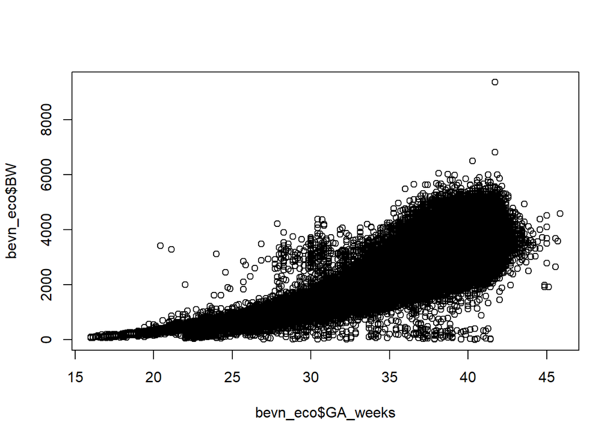

```r
plot(bevn_eco$GA_weeks,bevn_eco$BW) #BW and GA, all birthweights
```

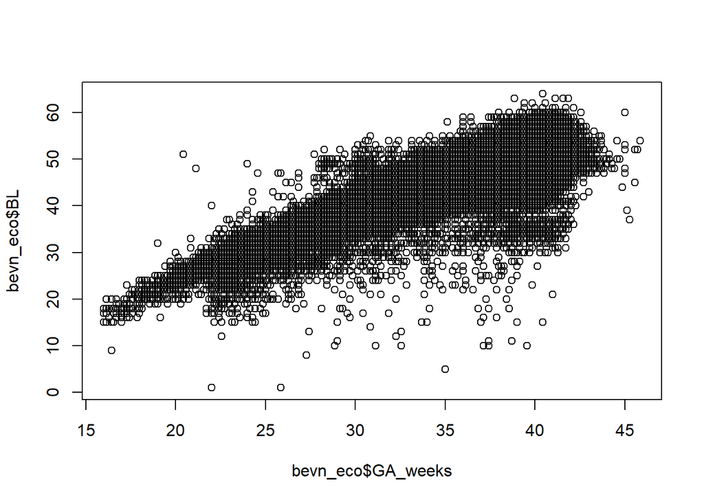

```r
plot(bevn_eco$GA_weeks, bevn_eco$BL) #BL and GA, all birthlengths
```

```r
BW_normal <- subset(bevn_eco, BW>100 & BW <8000 & GA_weeks>20)
summary(BW_normal$BW)
```

```
##    Min. 1st Qu.  Median    Mean 3rd Qu.    Max.
##     101    3000    3320    3286    3640    6820
```

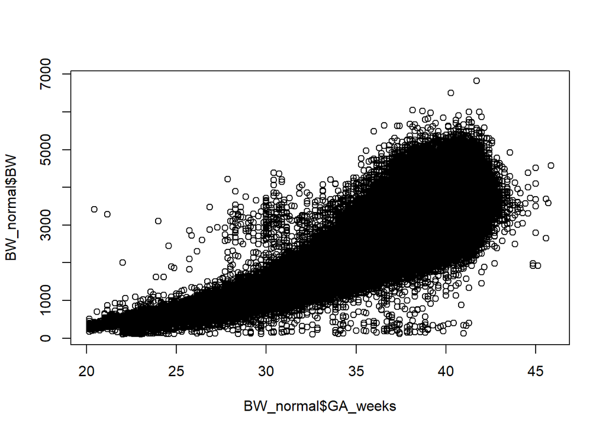

```r
plot(BW_normal$GA_weeks, BW_normal$BW) #BW and GA, BW ]100;8000[
```

```r
BL_normal <- subset(bevn_eco, BL>10 & BL <60  & GA_weeks>20)
summary(BL_normal$BL)
```

```
##    Min. 1st Qu.  Median    Mean 3rd Qu.    Max.
##   11.00   48.00   50.00   49.32   51.00   59.00
```

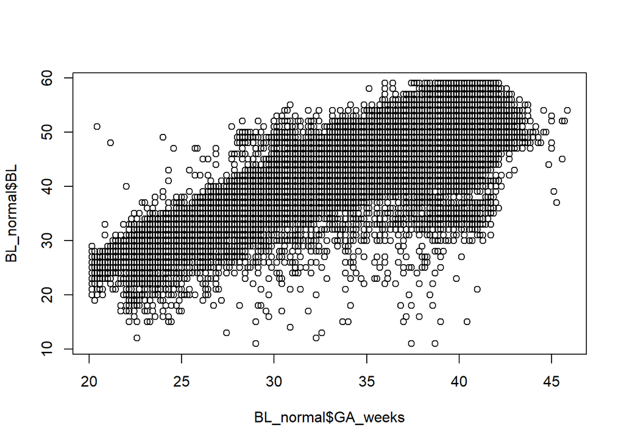

```r
plot(BL_normal$GA_weeks, BL_normal$BL) #BL and GA, BL ]10;60[
```

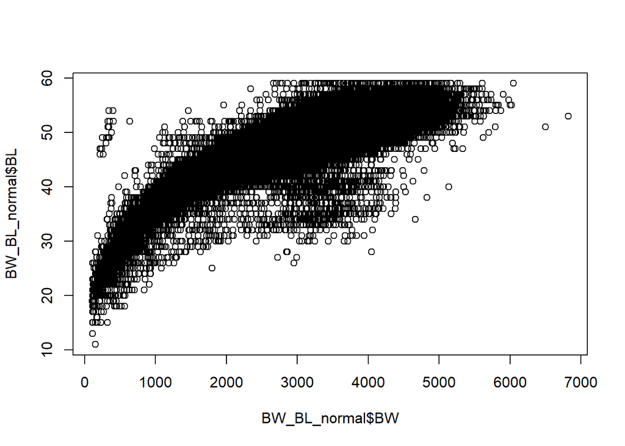

```r
BW_BL_normal <- subset(bevn_eco, BL>10 & BL <60 & BW>100 & BW <8000  & GA_weeks>20)
plot(BW_BL_normal$BW,BW_BL_normal$BL) #BW and BL
```

# UNIVARIATE ANALYSIS

## BIRTHWEIGHT

### Birthweight change through the years: Simple model

```r
##boxplot(bevn_eco$birthyear, bevn_eco$BW) ##doesnt work
m_BW_years <- lm(BW~birthyear, data=bevn_eco)
summary(m_BW_years)
```

```
##
## Call:
## lm(formula = BW ~ birthyear, data = bevn_eco)
##
## Residuals:
##     Min      1Q  Median      3Q     Max
## -3283.1  -284.8    36.8   353.9  6064.9
##
## Coefficients:
##              Estimate Std. Error t value Pr(>|t|)
## (Intercept) 2756.8095   235.3289  11.715   <2e-16 ***
## birthyear      0.2623     0.1169   2.244   0.0248 *
## ---
## Signif. codes:  0 '***' 0.001 '**' 0.01 '*' 0.05 '.' 0.1 ' ' 1
##
## Residual standard error: 566 on 1278390 degrees of freedom
##   (132494 observations deleted due to missingness)
## Multiple R-squared:  3.938e-06,  Adjusted R-squared:  3.156e-06
## F-statistic: 5.034 on 1 and 1278390 DF,  p-value: 0.02485
```

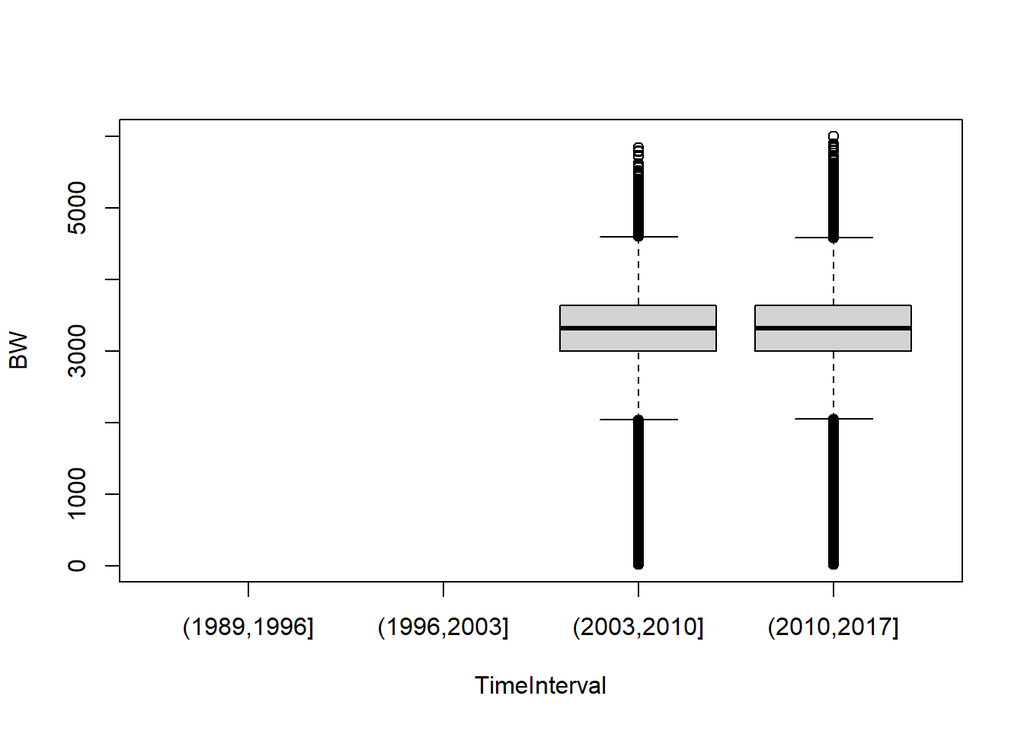

```r
bevn_eco$TimeInterval <- cut(bevn_eco$birthyear, breaks=c(1989, 1996, 2003, 2010, 2017))
boxplot(BW~TimeInterval, data=bevn_eco)
```

```r
meanBW <- mean(bevn_eco$BW)

# BW_time3 <- lm(BW~year+month, data=bevn_eco) ##doesnt work
## m_BW_time3 <- lm(BW~ factor(birthyear)+factor(birthmonth), data=bevn_eco) ##to not interpret too much

m_BW_time2 <- lm(BW~birthdate2, data=bevn_eco)
summary(m_BW_time2)
```

```
##
## Call:
## lm(formula = BW ~ birthdate2, data = bevn_eco)
##
## Residuals:
##     Min      1Q  Median      3Q     Max
## -3283.1  -284.7    36.6   353.9  6064.9
##
## Coefficients:
##              Estimate Std. Error t value Pr(>|t|)
## (Intercept) 3.274e+03  5.119e+00 639.542   <2e-16 ***
## birthdate2  6.790e-04  3.194e-04   2.126   0.0335 *
## ---
## Signif. codes:  0 '***' 0.001 '**' 0.01 '*' 0.05 '.' 0.1 ' ' 1
##
## Residual standard error: 566 on 1278390 degrees of freedom
##   (132494 observations deleted due to missingness)
## Multiple R-squared:  3.536e-06,  Adjusted R-squared:  2.754e-06
## F-statistic: 4.521 on 1 and 1278390 DF,  p-value: 0.03349
```

### BW related to sex

```r
m_BW_sex <- lm(BW~sex, data=bevn_eco)
summary(m_BW_sex) #female is the reference
```

```
##
## Call:
## lm(formula = BW ~ sex, data = bevn_eco)
##
## Residuals:
##     Min      1Q  Median      3Q     Max
## -3326.2  -279.2    40.8   350.8  6001.8
##
## Coefficients:
##              Estimate Std. Error t value Pr(>|t|)
## (Intercept) 3216.8094     0.7130  4511.4   <2e-16 ***
## sexM         132.3492     0.9947   133.1   <2e-16 ***
## ---
## Signif. codes:  0 '***' 0.001 '**' 0.01 '*' 0.05 '.' 0.1 ' ' 1
##
## Residual standard error: 562.1 on 1278390 degrees of freedom
##   (132494 observations deleted due to missingness)
## Multiple R-squared:  0.01366,    Adjusted R-squared:  0.01366
## F-statistic: 1.771e+04 on 1 and 1278390 DF,  p-value: < 2.2e-16
```

```r
table(bevn_eco$sex)
```

```
##
##      F      M
## 685779 725107
```

### BW related to maternal age

```r
m_BW_mat_age <- lm(BW~mat_age, data=bevn_eco)
summary(m_BW_mat_age)
```

```
##
## Call:
## lm(formula = BW ~ mat_age, data = bevn_eco)
##
## Residuals:
##     Min      1Q  Median      3Q     Max
## -3282.5  -285.3    38.3   352.1  6053.1
##
## Coefficients:
##               Estimate Std. Error t value Pr(>|t|)
## (Intercept) 3349.11930    3.14281 1065.65   <2e-16 ***
## mat_age       -2.05076    0.09897  -20.72   <2e-16 ***
## ---
## Signif. codes:  0 '***' 0.001 '**' 0.01 '*' 0.05 '.' 0.1 ' ' 1
##
## Residual standard error: 565.9 on 1278390 degrees of freedom
##   (132494 observations deleted due to missingness)
## Multiple R-squared:  0.0003358,  Adjusted R-squared:  0.000335
## F-statistic: 429.4 on 1 and 1278390 DF,  p-value: < 2.2e-16
```

BW decreases significantly when maternal age increases.

### BW related to GA

```r
m_BW_GA <- lm(BW ~GA_weeks, data=bevn_eco)
summary(m_BW_GA)
```

```
##
## Call:
## lm(formula = BW ~ GA_weeks, data = bevn_eco)
##
## Residuals:
##     Min      1Q  Median      3Q     Max
## -3669.6  -275.9   -14.0   261.8  5599.0
##
## Coefficients:
##               Estimate Std. Error t value Pr(>|t|)
## (Intercept) -4045.0213     7.1555  -565.3   <2e-16 ***
## GA_weeks      186.9154     0.1822  1025.8   <2e-16 ***
## ---
## Signif. codes:  0 '***' 0.001 '**' 0.01 '*' 0.05 '.' 0.1 ' ' 1
##
## Residual standard error: 412.2 on 1192266 degrees of freedom
##   (218618 observations deleted due to missingness)
## Multiple R-squared:  0.4688, Adjusted R-squared:  0.4688
## F-statistic: 1.052e+06 on 1 and 1192266 DF,  p-value: < 2.2e-16
```

BW increases with GA : each GA weeks is associated with an increase of 187g.

## STILLBIRTH

### stillbirth related to maternal age

```r
m_SB_mat_age <- glm(stillbirth~mat_age,
                    family= "binomial",data=bevn_eco)
summary(m_SB_mat_age)
```

```
##
## Call:
## glm(formula = stillbirth ~ mat_age, family = "binomial", data = bevn_eco)
##
## Deviance Residuals:
##     Min       1Q   Median       3Q      Max
## -0.1081  -0.0907  -0.0892  -0.0872   3.3877
##
## Coefficients:
##              Estimate Std. Error z value Pr(>|z|)
## (Intercept) -5.878441   0.085205 -68.992  < 2e-16 ***
## mat_age      0.011035   0.002654   4.159  3.2e-05 ***
## ---
## Signif. codes:  0 '***' 0.001 '**' 0.01 '*' 0.05 '.' 0.1 ' ' 1
##
## (Dispersion parameter for binomial family taken to be 1)
##
##     Null deviance: 72806  on 1410885  degrees of freedom
## Residual deviance: 72789  on 1410884  degrees of freedom
## AIC: 72793
##
## Number of Fisher Scoring iterations: 8
```

```r
exp(coef(summary(m_SB_mat_age)))[,"Estimate"]
```

```
## (Intercept)     mat_age
## 0.002799146 1.011095944
```

```r
#exp(confint(m_SB_mat_age))  doesnt work


m_SB_partiy <- glm(stillbirth~parity,
                    family= "binomial",data=bevn_eco)
summary(m_SB_partiy)
```

```
##
## Call:
## glm(formula = stillbirth ~ parity, family = "binomial", data = bevn_eco)
##
## Deviance Residuals:
##        Min          1Q      Median          3Q         Max
## -2.409e-06  -2.409e-06  -2.409e-06  -2.409e-06  -2.409e-06
##
## Coefficients:
##               Estimate Std. Error z value Pr(>|z|)
## (Intercept) -2.657e+01  6.474e+02  -0.041    0.967
## parity      -5.099e-14  3.349e+02   0.000    1.000
##
## (Dispersion parameter for binomial family taken to be 1)
##
##     Null deviance: 0.0000e+00  on 1405285  degrees of freedom
## Residual deviance: 8.1529e-06  on 1405284  degrees of freedom
##   (5600 observations deleted due to missingness)
## AIC: 4
##
## Number of Fisher Scoring iterations: 25
```

## MULTIVARIATE

```r
m_BW <- lm(BW ~ GA_weeks + birthdate2 + mat_age + parity + sex, data=bevn_eco)
summary(m_BW)
```

```
##
## Call:
## lm(formula = BW ~ GA_weeks + birthdate2 + mat_age + parity +
##     sex, data = bevn_eco)
##
## Residuals:
##     Min      1Q  Median      3Q     Max
## -3610.5  -266.9   -12.1   253.6  5577.7
##
## Coefficients:
##               Estimate Std. Error  t value Pr(>|t|)
## (Intercept) -4.272e+03  8.803e+00 -485.312   <2e-16 ***
## GA_weeks     1.892e+02  1.893e-01  999.116   <2e-16 ***
## birthdate2  -3.559e-03  2.526e-04  -14.092   <2e-16 ***
## mat_age      3.309e-02  7.556e-02    0.438    0.661
## parity       7.128e+01  4.453e-01  160.088   <2e-16 ***
## sexM         1.466e+02  7.346e-01  199.500   <2e-16 ***
## ---
## Signif. codes:  0 '***' 0.001 '**' 0.01 '*' 0.05 '.' 0.1 ' ' 1
##
## Residual standard error: 400 on 1187175 degrees of freedom
##   (223705 observations deleted due to missingness)
## Multiple R-squared:  0.4689, Adjusted R-squared:  0.4689
## F-statistic: 2.096e+05 on 5 and 1187175 DF,  p-value: < 2.2e-16
```

```r
#without mat age
m_BW1 <- lm(BW ~ GA_weeks + birthdate2 + parity + sex, data=bevn_eco)
summary(m_BW1)
```

```
##
## Call:
## lm(formula = BW ~ GA_weeks + birthdate2 + parity + sex, data = bevn_eco)
##
## Residuals:
##     Min      1Q  Median      3Q     Max
## -3610.5  -266.9   -12.1   253.6  5577.6
##
## Coefficients:
##               Estimate Std. Error t value Pr(>|t|)
## (Intercept) -4.271e+03  8.487e+00  -503.2   <2e-16 ***
## GA_weeks     1.891e+02  1.890e-01  1000.9   <2e-16 ***
## birthdate2  -3.551e-03  2.519e-04   -14.1   <2e-16 ***
## parity       7.133e+01  4.311e-01   165.5   <2e-16 ***
## sexM         1.466e+02  7.346e-01   199.5   <2e-16 ***
## ---
## Signif. codes:  0 '***' 0.001 '**' 0.01 '*' 0.05 '.' 0.1 ' ' 1
##
## Residual standard error: 400 on 1187176 degrees of freedom
##   (223705 observations deleted due to missingness)
## Multiple R-squared:  0.4689, Adjusted R-squared:  0.4689
## F-statistic: 2.62e+05 on 4 and 1187176 DF,  p-value: < 2.2e-16
```